# Taking Questions: Week 11

Stats Corner

November 25, 2016

```r
extremes <-
  games_played %>%
  filter((year > 2009 & (rk == 10 & W == 0 | rk == 2 & W == 1)) | (year == 2009 & (rk == 9 & W == 0 | rk == 2 & W == 1)))

extremesX2 <-
  games_played %>%
  filter((year > 2009 & (rk == 10 & W == 0 | rk == 2 & W == 1)) | (year == 2009 & (rk == 9 & W == 0 | rk == 2 & W == 1))|
         (year > 2009 & ((rk == 9 & W == 0 | rk == 3 & W == 1)) | (year == 2009 & (rk == 8 & W == 0 | rk == 3 & W == 1 ))))
```

#### Why wins and losses aren’t a good metric

There is no such thing as playing defense in fantasy football; you can’t stop your opponent from scoring points. Last week, Harrington lost to Hartman despite scoring the second most points in the league and Regan beat Ready despite scoring the second fewest. Should Harrington go into panic mode from losing? Should Regan let his chest swell with the pride from victory? Clearly not. In the history of our league (from Week 1 in 2009 through Week 11 in 2016) we’ve had 599 games played. In 30 of those games we’ve had a situtaion like the ones we experienced last week. Admittedly those are rare cases as one of those situations only happens about 4 times per season. If you expand the universe to scoring the third most points and losing, or scoring the third fewest and winning and we’re up to about 14% of the time or 11 times per season (slightly less than once/week) we’d see a situation that appears to be unfair.

We could keep expanding this to less and less “unfair” outcomes but hopefully I’ve made my point that Wins and Losses in and of themselves don’t indicate strong fantasy performance.

#### Enter Proportional Wins (PW)

PW = % of teams in a given week you would have beaten.

For example: if you score the most points in a week you would have beaten all of the other teams in the league. 11/11 = 1, so you earn 1 PW. Had you scored the least amount of ponts you would have beaten 0 other teams so you’d earn 0/11 = 0 PW.

The PW does a few things: **Conserves Total Wins in a Week** Every week there are only 6 wins to be earned, if we forget about ties. PW has the same property. Wins are given out to 6 teams and 6 teams only, whereas the 6 PW are distributed unevenly to 11 teams (lowest scoring team earns 0).

**Awards Consistency Throughout the Season**

How Luck Comes Into Play

## The influence of the schedule

Before last season we made the change to a more balanced schedule. Now you play each team at least once, and two teams twice. Still due to weekly variations we can see dramatically different results.

[figure not shown]

```r
owners <- games_played %>% filter(year == 2016) %>% group_by(owner) %>% select(owner) %>% slice(1)
season2016 <- filter(games_played, year == 2016)

shinyApp(

  ui = fluidPage(
    selectInput("owner",
                label = h3("Choose One"),
                choices = owners,
                selected = "Olson"),
    plotOutput("game_plot")
  ),

  server = function(input, output) {
    output$game_plot <- renderPlot({
      ggplot(data = season2016,
                aes(x = week,
                    y = points,
                    shape = as.factor(W))) +
      geom_point() +
      scale_x_continuous("Week", breaks = c(1:11)) +
      geom_line(data = season2016 %>% ungroup() %>% filter(rk == 6),
              aes(x = week, y = points),
              linetype = 2) +
      geom_point(data = season2016 %>% filter(owner == input$owner) %>% select(week,points,W),
                aes(week,points),
                colour = 'red')

    })
  }
)
```

Shiny applications not supported in static R Markdown documents

## “…I’m interested in whether week-to-week consistency is taken into account to proportionate wins… usually you don’t need to score 160 to win, 110-120 will usually do it. So it would seem like better week-to-week consistency would improve win totals. Is this factored into the PWs and Luck?”

Indeed it is, and that’s the whole point. It’s very easy to identify the extremes (score the second most and lose) but less easy to identify some of the marginal cases. PW quantifies for exactly that.

## “I actually would be interested in seeing the graph of likelihood of victory based on points scored.”

```r
logistic_fit <- glm(data = games_played,
                    W ~ points,
                    family = 'binomial')

library(pROC)
auc(logistic_fit$data$W,logistic_fit$fitted.values)
```

```
## Area under the curve: 0.8194
```

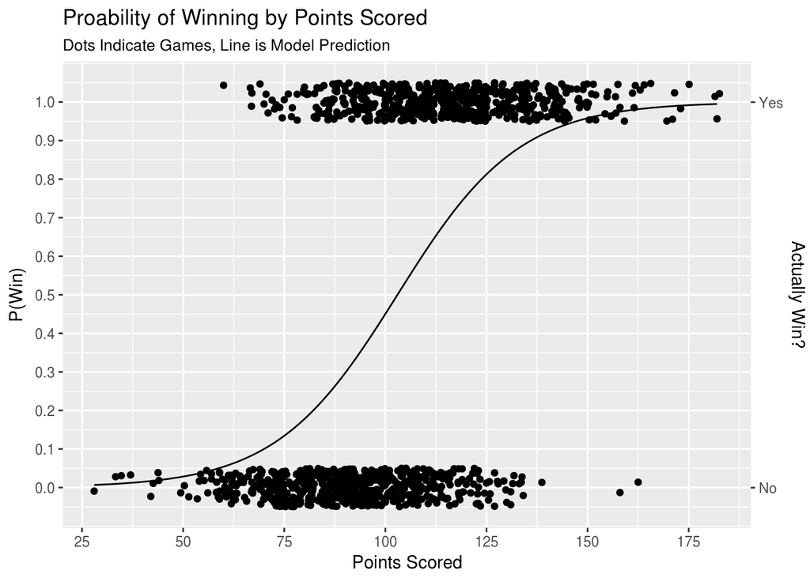

```r
points = seq(from = min(games_played$points),
               to = max(games_played$points),
               by = 1)
predicted_win = exp(logistic_fit$coef[1] + logistic_fit$coef[2]*points)/
  (1 + exp(logistic_fit$coef[1] + logistic_fit$coef[2]*points))

logistic_plot <- ggplot(data = games_played,
                        aes(x = points, y = W)
)

logistic_plot +
  geom_jitter(width = 0,
              height = 0.05) +
  scale_y_continuous("P(Win)",
                     breaks = seq(from=0,to=1,by=0.1),
                     sec.axis = sec_axis(trans = ~.,
                                         breaks = c(0,1),
                                         label = c("No","Yes"),
                                         name = "Actually Win?")) +
  geom_line(data = data.frame(points = points,W = predicted_win),
            aes(x = points, y = W)) +
  scale_x_continuous("Points Scored",
                     breaks = seq(from = 25, to = 175, by = 25)) +
  ggtitle("Proability of Winning by Points Scored",
          subtitle = "Dots Indicate Games, Line is Model Prediction")
```

Not sure what the point of interest is exactly, but the 50/50 point, where if you score that amount of points you are just as likely to win as lose, is 103 points.

## Record Chasing

### Hartman and Proportional Wins

```r
eleven_weeks_summary %>%
  ungroup() %>%
  arrange(-pw_sum) %>%
  slice(1:10) %>%
  left_join(.,season_summary %>% select(year,owner,pw_sum,pw_rank), by = c("year","owner")) %>%
  select(1,2,3,7,8) %>%
  `colnames<-`(c("Year", "Owner", "PW Through 10 Weeks", "PW Season Total","All Time Rank")) %>%
  kable(digits = 2)
```

| Year | Owner | PW Through 10 Weeks | PW Season Total | All Time Rank |
| --- | --- | --- | --- | --- |
| 2014 | Skrzyszewski | 8.45 | 9.45 | 2 |
| 2011 | Shokunbi | 8.36 | 10.09 | 1 |
| 2016 | Hartman | 8.09 | NA | NA |
| 2013 | Ready | 7.73 | 9.18 | 4 |
| 2012 | Ready | 7.64 | 9.09 | 5 |
| 2010 | Ready | 7.55 | 9.00 | 6 |
| 2011 | Ready | 7.55 | 8.36 | 10 |
| 2011 | Harrington | 7.45 | 9.27 | 3 |
| 2009 | Regan | 7.44 | 9.00 | 6 |
| 2009 | Shokunbi | 7.44 | 9.00 | 6 |

### Hartman and Total Points

```r
eleven_weeks_summary %>%
  ungroup() %>%
  arrange(-points_sum) %>%
  slice(1:10) %>%
  left_join(.,season_summary %>% select(year,owner,points_sum,points_rank), by = c("year","owner")) %>%
  select(1,2,6,7,8) %>%
  `colnames<-`(c("Year", "Owner", "Points Through 11 Weeks", "Points Season Total","All Time Rank")) %>%
  kable(digits = 2)
```

| Year | Owner | Points Through 11 Weeks | Points Season Total | All Time Rank |
| --- | --- | --- | --- | --- |
| 2015 | Harrington | 1348.7 | 1581.1 | 2 |
| 2013 | Ready | 1341.0 | 1577.3 | 3 |
| 2011 | Shokunbi | 1339.2 | 1615.2 | 1 |
| 2016 | Hartman | 1322.7 | NA | NA |
| 2014 | Skrzyszewski | 1316.0 | 1542.3 | 5 |
| 2011 | Ready | 1294.1 | 1501.5 | 9 |
| 2015 | Ready | 1287.2 | 1515.6 | 7 |
| 2013 | Hartman | 1278.9 | 1461.9 | 16 |
| 2012 | Ready | 1267.7 | 1502.0 | 8 |
| 2009 | Regan | 1266.0 | 1494.0 | 10 |

### Olson and Luck

```r
eleven_weeks_summary %>%
  ungroup() %>%
  arrange(-luck_sum) %>%
  slice(1:10) %>%
  left_join(.,season_summary %>% select(year,owner,luck_sum,luck_rank_top), by = c("year","owner")) %>%
  select(1,2,4,7,8) %>%
  `colnames<-`(c("Year","Owner","Luck Through 10 Weeks","Season Total Luck","All Time Rank")) %>%
  kable(digits = 2)
```

| Year | Owner | Luck Through 10 Weeks | Season Total Luck | All Time Rank |
| --- | --- | --- | --- | --- |
| 2013 | Thieneman | 3.27 | 3.82 | 2 |
| 2011 | Olson | 3.09 | 3.55 | 3 |
| 2010 | Higdon | 2.91 | 3.91 | 1 |
| 2016 | Olson | 2.82 | NA | NA |
| 2015 | Higdon | 2.36 | 2.00 | 7 |
| 2016 | Matovina | 2.09 | NA | NA |
| 2013 | Harrington | 2.00 | 1.82 | 8 |
| 2012 | McShane | 1.82 | 2.27 | 5 |
| 2012 | Thieneman | 1.82 | 2.45 | 4 |
| 2014 | Regan | 1.73 | 1.64 | 10 |

### Kane and (Un)Luck

```r
eleven_weeks_summary %>%
  ungroup() %>%
  arrange(luck_sum) %>%
  slice(1:10) %>%
  left_join(.,season_summary %>% select(year,owner,luck_sum,luck_rank_btm), by = c("year","owner")) %>%
  select(1,2,4,7,8) %>%
  `colnames<-`(c("Year","Owner","Luck Through 10 Weeks","Season Total Luck","All Time Rank")) %>%
  kable(digits = 2)
```

| Year | Owner | Luck Through 10 Weeks | Season Total Luck | All Time Rank |
| --- | --- | --- | --- | --- |
| 2012 | Higdon | -3.45 | -3.73 | 1 |
| 2016 | Kane | -3.00 | NA | NA |
| 2014 | Ready | -2.45 | -3.18 | 2 |
| 2015 | Harrington | -2.36 | -1.55 | 8 |
| 2013 | Higdon | -2.18 | -2.73 | 3 |
| 2010 | Kane | -2.09 | -1.36 | 10 |
| 2015 | McShane | -1.91 | -1.09 | 12 |
| 2012 | Shokunbi | -1.82 | -1.36 | 10 |
| 2014 | Hartman | -1.82 | -1.00 | 14 |
| 2011 | Skrzyszewski | -1.73 | -1.55 | 8 |

### Kane and Points Against

```r
eleven_weeks_summary %>%
  ungroup() %>%
  arrange(-pa_sum) %>%
  slice(1:10) %>%
  left_join(.,season_summary %>% select(year,owner,pa_sum,pa_rank), by = c("year","owner")) %>%
  select(1,2,5,7,8) %>%
  `colnames<-`(c("Year", "Owner", "Points Against Through 11 Weeks", "Points Against Season Total","All Time Rank")) %>%
  kable(digits = 2)
```

| Year | Owner | Points Against Through 11 Weeks | Points Against Season Total | All Time Rank |
| --- | --- | --- | --- | --- |
| 2012 | Higdon | 1297.5 | 1488.8 | 1 |
| 2013 | Higdon | 1264.0 | 1475.3 | 3 |
| 2016 | Kane | 1262.3 | NA | NA |
| 2013 | Olson | 1251.8 | 1480.3 | 2 |
| 2015 | Thieneman | 1241.5 | 1459.9 | 6 |
| 2014 | Hartman | 1233.6 | 1376.2 | 24 |
| 2011 | Thieneman | 1228.6 | 1364.5 | 28 |
| 2015 | McShane | 1218.2 | 1405.4 | 17 |
| 2015 | Harrington | 1206.8 | 1427.2 | 14 |
| 2016 | Skrzyszewski | 1203.1 | NA | NA |

### Harris, Ready and Fewest Total Points

```r
eleven_weeks_summary %>%
  ungroup() %>%
  arrange(points_sum) %>%
  slice(1:10) %>%
  left_join(.,season_summary %>% select(year,owner,points_sum,points_rank_btm), by = c("year","owner")) %>%
  select(1,2,6,7,8) %>%
  `colnames<-`(c("Year", "Owner", "Points Through 11 Weeks", "Points Season Total","All Time Rank")) %>%
  kable(digits = 2)
```

| Year | Owner | Points Through 11 Weeks | Points Season Total | All Time Rank |
| --- | --- | --- | --- | --- |
| 2010 | Thieneman | 851.0 | 1033.0 | 1 |
| 2015 | Thieneman | 901.3 | 1115.5 | 6 |
| 2016 | Ready | 907.6 | NA | NA |
| 2011 | Matovina | 908.0 | 1060.4 | 2 |
| 2016 | Harris | 934.0 | NA | NA |
| 2011 | Thieneman | 935.2 | 1115.3 | 5 |
| 2012 | Matovina | 940.5 | 1081.8 | 4 |
| 2010 | Harrington | 945.0 | 1074.0 | 3 |
| 2016 | McShane | 966.5 | NA | NA |
| 2014 | Higdon | 971.1 | 1185.9 | 9 |

### Harris, Ready and Fewest Proportional Wins